# RNA-Seq DE analyis

A.Thomas

```r
register(MulticoreParam(4))
```

Function to plot barplot for pathway analysis

Function to plot dotplot for pathway analysis

Function to get genes in each pathway

```r
getkegggenes = function(id){
  #cat(id)
  query = keggGet(id)
  geneid_details = query[[1]]$GENE
  if(length(geneid_details) > 0){
    details = geneid_details[c(FALSE,TRUE)]
    genename = tstrsplit(details, ";")[[1]]
  }else
    genename = NA
  return(genename)
}
```

Function to call Kegg pathway

Write output to files

plotfigues

create directories

read gtf details

Read counts table

```
[1] 63677    45
[1] 36228    45
```

```r
design.matrix = read.table(paste0(path,"RNAseq_design_matrix.tsv"),sep = "\t",
                           header = T,row.names = 1)
design.matrix
```

|  | parentype | targetorgan | cellline | parenttype | dissociationstatus | culture | dissociation_treatment | celllinetargetorgan |
| --- | --- | --- | --- | --- | --- | --- | --- | --- |
| X07H | parent | H | Brx07 | parent | no | yes | no | Brx07H |
| X07HD.R1 | parent | H | Brx07 | parent | yes | yes | lungdisso | Brx07H |
| X07HD.R2 | parent | H | Brx07 | parent | yes | yes | lungdisso | Brx07H |
| X07HR | parent | H | Brx07 | parent | no | yes | no | Brx07H |
| X07H.R3 | parent | H | Brx07 | parent | no | yes | no | Brx07H |
| X07kidn.80.1 | nonparent | kidn | Brx07 | nonparent | yes | yes | lungdisso | Brx07kidn |
| X07lung.28.2 | nonparent | lung | Brx07 | nonparent | yes | no | lungdisso | Brx07lung |
| X07lung.30.2 | nonparent | lung | Brx07 | nonparent | yes | yes | lungdisso | Brx07lung |
| X07lung.71.1 | nonparent | lung | Brx07 | nonparent | yes | yes | lungdisso | Brx07lung |
| X07lung.77.1 | nonparent | lung | Brx07 | nonparent | yes | no | lungdisso | Brx07lung |

[output cut: 35 more lines]

DESeq2 call

```r
dds  = DESeqDataSetFromMatrix(countData= df, colData= design.matrix,
                      ~ culture + dissociation_treatment +  celllinetargetorgan)
dds =  DESeq(dds)#, minReplicatesForReplace=Inf)
```

```r
resultsNames(dds)
```

```
 [1] "Intercept"                                      "culture_yes_vs_no"                              "dissociation_treatment_braindisso_vs_bonedisso"
 [4] "dissociation_treatment_lungdisso_vs_bonedisso"  "dissociation_treatment_no_vs_bonedisso"         "celllinetargetorgan_Brx07kidn_vs_Brx07H"
 [7] "celllinetargetorgan_Brx07lung_vs_Brx07H"        "celllinetargetorgan_Brx07ovar_vs_Brx07H"        "celllinetargetorgan_Brx42brai_vs_Brx07H"
[10] "celllinetargetorgan_Brx42H_vs_Brx07H"           "celllinetargetorgan_Brx42ovar_vs_Brx07H"        "celllinetargetorgan_Brx50bone_vs_Brx07H"
[13] "celllinetargetorgan_Brx50brai_vs_Brx07H"        "celllinetargetorgan_Brx50H_vs_Brx07H"           "celllinetargetorgan_Brx68bone_vs_Brx07H"
[16] "celllinetargetorgan_Brx68brai_vs_Brx07H"        "celllinetargetorgan_Brx68H_vs_Brx07H"           "celllinetargetorgan_Brx68lung_vs_Brx07H"
```

write normalized counts

```r
write.table(counts(dds, normalized=T) ,file =
      "RNAseq_DESEQ2_normalizedcounts.tsv",sep = "\t",quote = F,col.names = NA)
write.table(assay(rld), paste0("heatmap/","countdata_defaultvst.tsv"),sep="\t",
            row.names = TRUE,quote = FALSE,col.names = NA)
save.image("RNASeq_differential_unique_dissociationtreatment.RData")
#load("RNASeq_differential_unique_dissociationtreatment.RData")
```

For plotting the MA plot, it is better to plot with shrunken log fold change. We will use DESeq2 default LFC shrinkage with normal prior. Since we are using numerical vector for constrast for most of analysis,we need to run DESEQ function again with betaprior=True for lfcshrinkage to work https://support.bioconductor.org/p/106107/

DESeq2 call with LFC shrinkage

```r
dds1  = DESeqDataSetFromMatrix(countData= df, colData= design.matrix,
                    ~ culture + dissociation_treatment +  celllinetargetorgan)
dds1 =  DESeq(dds1, betaPrior = TRUE)#, minReplicatesForReplace=Inf)
```

Function to plot heatmap

1.1 Brx07lung vs parent

```r
outputname = "Comparison1.1_Brx07lung-vs-07parents"
res = results(dds, alpha=0.05, contrast =
                c("celllinetargetorgan","Brx07lung","Brx07H"))
keep1 = rowSums(counts(dds[,dds$celllinetargetorgan %in%
                             c("Brx07lung")]) >= 10) >= 2
keep2 = rowSums(counts(dds[,dds$celllinetargetorgan %in%
                             c("Brx07H")]) >= 10) >= 2
res.sub = res[keep1 & keep2,]
summary(res.sub)
```

```
out of 16798 with nonzero total read count
adjusted p-value < 0.05
LFC > 0 (up)     : 639, 3.8%
LFC < 0 (down)   : 558, 3.3%
outliers [1]     : 14, 0.083%
low counts [2]   : 385, 2.3%
(mean count < 8)
[1] see 'cooksCutoff' argument of ?results
[2] see 'independentFiltering' argument of ?results
```

```r
rld.sub = rld[ , rld$celllinetargetorgan %in% c("Brx07lung", "Brx07H") ]
print(outputname)
```

```
[1] "Comparison1.1_Brx07lung-vs-07parents"
```

```r
colData(rld.sub)
```

```
DataFrame with 9 rows and 9 columns
             parentype targetorgan cellline parenttype dissociationstatus  culture dissociation_treatment celllinetargetorgan sizeFactor
              <factor>    <factor> <factor>   <factor>           <factor> <factor>               <factor>            <factor>  <numeric>
X07H            parent           H    Brx07     parent                 no      yes                     no              Brx07H  1.0159121
X07HD.R1        parent           H    Brx07     parent                yes      yes              lungdisso              Brx07H  1.0714694
X07HD.R2        parent           H    Brx07     parent                yes      yes              lungdisso              Brx07H  0.9776352
X07HR           parent           H    Brx07     parent                 no      yes                     no              Brx07H  1.0533864
X07H.R3         parent           H    Brx07     parent                 no      yes                     no              Brx07H  1.0716432
X07lung.28.2 nonparent        lung    Brx07  nonparent                yes       no              lungdisso           Brx07lung  0.7791621
X07lung.30.2 nonparent        lung    Brx07  nonparent                yes      yes              lungdisso           Brx07lung  0.8302310
X07lung.71.1 nonparent        lung    Brx07  nonparent                yes      yes              lungdisso           Brx07lung  1.0974375
X07lung.77.1 nonparent        lung    Brx07  nonparent                yes       no              lungdisso           Brx07lung  0.8950528
```

```r
createoutput(res.sub, outputname)
plotfigures(rld.sub)
kegg(res.sub, outputname,"hg19")
plotheatmap(res.sub,rld1,20,outputname,"parenttype")
```

```r
outputname = "Comparison1.2_Brx07ovar-vs-07parents"
res = results(dds, alpha=0.05,
              contrast = c("celllinetargetorgan","Brx07ovar","Brx07H"))
keep1 = rowSums(counts(dds[,dds$celllinetargetorgan %in%
                             c("Brx07ovar")]) >= 10) >= 2
keep2 = rowSums(counts(dds[,dds$celllinetargetorgan %in%
                             c("Brx07H")]) >= 10) >= 2
res.sub = res[keep1 & keep2,]
summary(res.sub)
```

```
out of 16636 with nonzero total read count
adjusted p-value < 0.05
LFC > 0 (up)     : 1816, 11%
LFC < 0 (down)   : 1578, 9.5%
outliers [1]     : 14, 0.084%
low counts [2]   : 253, 1.5%
(mean count < 7)
[1] see 'cooksCutoff' argument of ?results
[2] see 'independentFiltering' argument of ?results
```

```r
rld.sub = rld[ , rld$celllinetargetorgan %in% c("Brx07ovar", "Brx07H") ]
print(outputname)
```

```
[1] "Comparison1.2_Brx07ovar-vs-07parents"
```

```r
colData(rld.sub)
```

```
DataFrame with 9 rows and 9 columns
             parentype targetorgan cellline parenttype dissociationstatus  culture dissociation_treatment celllinetargetorgan sizeFactor
              <factor>    <factor> <factor>   <factor>           <factor> <factor>               <factor>            <factor>  <numeric>
X07H            parent           H    Brx07     parent                 no      yes                     no              Brx07H  1.0159121
X07HD.R1        parent           H    Brx07     parent                yes      yes              lungdisso              Brx07H  1.0714694
X07HD.R2        parent           H    Brx07     parent                yes      yes              lungdisso              Brx07H  0.9776352
X07HR           parent           H    Brx07     parent                 no      yes                     no              Brx07H  1.0533864
X07H.R3         parent           H    Brx07     parent                 no      yes                     no              Brx07H  1.0716432
X07ovar.12.1 nonparent        ovar    Brx07  nonparent                yes      yes              lungdisso           Brx07ovar  0.9179032
X07ovar.27.2 nonparent        ovar    Brx07  nonparent                yes       no              lungdisso           Brx07ovar  0.9742657
X07ovar.28.2 nonparent        ovar    Brx07  nonparent                yes       no              lungdisso           Brx07ovar  1.0663069
X07ovar.30.2 nonparent        ovar    Brx07  nonparent                yes       no              lungdisso           Brx07ovar  0.7617778
```

```r
createoutput(res.sub, outputname)
plotfigures(rld.sub)
kegg(res.sub, outputname,"hg19")
```

2.1 Brx42brai vs parent

```r
outputname = "Comparison2.1_Brx42brai-vs-42parents"
res = results(dds, alpha=0.05,
              contrast = c("celllinetargetorgan","Brx42brai","Brx42H"))
keep1 = rowSums(counts(dds[,dds$celllinetargetorgan %in%
                             c("Brx42brai")]) >= 10) >= 2
keep2 = rowSums(counts(dds[,dds$celllinetargetorgan %in%
                             c("Brx42H")]) >= 10) >= 2
res.sub = res[keep1 & keep2,]
summary(res.sub)
```

```
out of 14028 with nonzero total read count
adjusted p-value < 0.05
LFC > 0 (up)     : 2139, 15%
LFC < 0 (down)   : 1804, 13%
outliers [1]     : 13, 0.093%
low counts [2]   : 16, 0.11%
(mean count < 4)
[1] see 'cooksCutoff' argument of ?results
[2] see 'independentFiltering' argument of ?results
```

```r
rld.sub = rld[ , rld$celllinetargetorgan %in% c("Brx42brai","Brx42H") ]
print(outputname)
```

```
[1] "Comparison2.1_Brx42brai-vs-42parents"
```

```r
colData(rld.sub)
```

```
DataFrame with 7 rows and 9 columns
             parentype targetorgan cellline parenttype dissociationstatus  culture dissociation_treatment celllinetargetorgan sizeFactor
              <factor>    <factor> <factor>   <factor>           <factor> <factor>               <factor>            <factor>  <numeric>
X42brai.66.1 nonparent        brai    Brx42  nonparent                yes       no             braindisso           Brx42brai  0.9056735
X42brai.74.1 nonparent        brai    Brx42  nonparent                yes       no             braindisso           Brx42brai  0.9426497
X42H            parent           H    Brx42     parent                 no      yes                     no              Brx42H  1.0963212
X42HD.R1        parent           H    Brx42     parent                yes      yes             braindisso              Brx42H  1.2570488
X42HD.R2        parent           H    Brx42     parent                yes      yes             braindisso              Brx42H  1.0958516
X42H.R3         parent           H    Brx42     parent                 no      yes                     no              Brx42H  1.3811384
X42H.R4         parent           H    Brx42     parent                 no      yes                     no              Brx42H  1.1448063
```

```r
createoutput(res.sub, outputname)
plotfigures(rld.sub)
kegg(res.sub, outputname,"hg19")
plotheatmap(res.sub,rld1,20,outputname,"parenttype")
```

```r
resLFC = lfcShrink(dds,contrast = c("celllinetargetorgan","Brx42brai","Brx42H"))
```

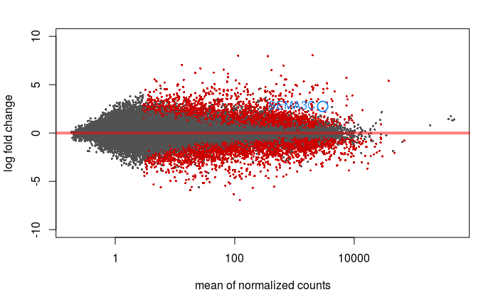

```r
topGene="ENSG00000075223"
DESeq2::plotMA(resLFC, ylim=c(-10,10))
with(res[topGene, ], {
  points(baseMean, log2FoldChange, col="dodgerblue", cex=2, lwd=2)
  text(baseMean, log2FoldChange, "SEMA3C", pos=2, col="dodgerblue")
})
```

```r
res = results(dds1, alpha=0.05, contrast =
                c("celllinetargetorgan","Brx42brai","Brx42H"))
keep1 = rowSums(counts(dds[,dds$celllinetargetorgan %in%
                             c("Brx42brai")]) >= 10) >= 2
keep2 = rowSums(counts(dds[,dds$celllinetargetorgan %in%
                             c("Brx42H")]) >= 10) >= 2
res.sub = res[keep1 & keep2,]
summary(res.sub)
```

```
out of 14028 with nonzero total read count
adjusted p-value < 0.05
LFC > 0 (up)     : 2172, 15%
LFC < 0 (down)   : 1845, 13%
outliers [1]     : 13, 0.093%
low counts [2]   : 10, 0.071%
(mean count < 3)
[1] see 'cooksCutoff' argument of ?results
[2] see 'independentFiltering' argument of ?results
```

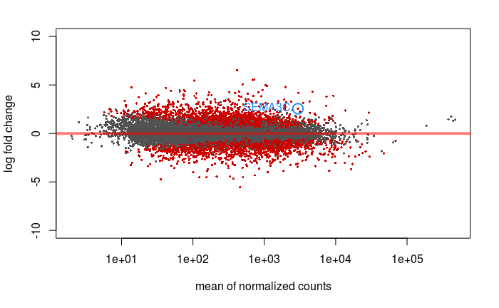

```r
topGene="ENSG00000075223"
DESeq2::plotMA(res.sub, ylim=c(-10,10))
with(res[topGene, ], {
  points(baseMean, log2FoldChange, col="dodgerblue", cex=2, lwd=2)
  text(baseMean, log2FoldChange, "SEMA3C", pos=2, col="dodgerblue")
})
```

2.2 Brx42ovar vs parent

```r
outputname = "Comparison2.2_Brx42ovar-vs-42parents"
res = results(dds, alpha=0.05, contrast =
                c("celllinetargetorgan","Brx42ovar","Brx42H"))
keep1 = rowSums(counts(dds[,dds$celllinetargetorgan %in%
                             c("Brx42ovar")]) >= 10) >= 2
keep2 = rowSums(counts(dds[,dds$celllinetargetorgan %in%
                             c("Brx42H")]) >= 10) >= 2
res.sub = res[keep1 & keep2,]
summary(res.sub)
```

```
out of 0 with nonzero total read count
adjusted p-value < 0.05
LFC > 0 (up)     : 0, NaN%
LFC < 0 (down)   : 0, NaN%
outliers [1]     : 0, NaN%
low counts [2]   : 0, NaN%
(mean count < 7)
[1] see 'cooksCutoff' argument of ?results
[2] see 'independentFiltering' argument of ?results
```

```r
rld.sub = rld[ , rld$celllinetargetorgan %in% c("Brx42ovar","Brx42H") ]
print(outputname)
```

```
[1] "Comparison2.2_Brx42ovar-vs-42parents"
```

```r
colData(rld.sub)
```

```
DataFrame with 6 rows and 9 columns
             parentype targetorgan cellline parenttype dissociationstatus  culture dissociation_treatment celllinetargetorgan sizeFactor
              <factor>    <factor> <factor>   <factor>           <factor> <factor>               <factor>            <factor>  <numeric>
X42H            parent           H    Brx42     parent                 no      yes                     no              Brx42H   1.096321
X42HD.R1        parent           H    Brx42     parent                yes      yes             braindisso              Brx42H   1.257049
X42HD.R2        parent           H    Brx42     parent                yes      yes             braindisso              Brx42H   1.095852
X42H.R3         parent           H    Brx42     parent                 no      yes                     no              Brx42H   1.381138
X42H.R4         parent           H    Brx42     parent                 no      yes                     no              Brx42H   1.144806
X42ovar.73.1 nonparent        ovar    Brx42  nonparent                yes       no              lungdisso           Brx42ovar   1.023255
```

```r
createoutput(res.sub, outputname)
plotfigures(rld.sub)
kegg(res.sub, outputname,"hg19")
plotheatmap(res.sub,rld1,20,outputname,"parenttype")
```

3.1 Brx50brai vs parent

```r
outputname = "Comparison3.1_Brx50brai-vs-50parents"
res = results(dds, alpha=0.05, contrast = c("celllinetargetorgan",
                                            "Brx50brai","Brx50H"))
keep1 = rowSums(counts(dds[,dds$celllinetargetorgan %in%
                             c("Brx50brai")]) >= 10) >= 2
keep2 = rowSums(counts(dds[,dds$celllinetargetorgan %in%
                             c("Brx50H")]) >= 10) >= 2
res.sub = res[keep1 & keep2,]
summary(res.sub)
```

```
out of 16784 with nonzero total read count
adjusted p-value < 0.05
LFC > 0 (up)     : 538, 3.2%
LFC < 0 (down)   : 524, 3.1%
outliers [1]     : 16, 0.095%
low counts [2]   : 382, 2.3%
(mean count < 7)
[1] see 'cooksCutoff' argument of ?results
[2] see 'independentFiltering' argument of ?results
```

```r
rld.sub = rld[ , rld$celllinetargetorgan %in% c("Brx50brai","Brx50H") ]
print(outputname)
```

```
[1] "Comparison3.1_Brx50brai-vs-50parents"
```

```r
colData(rld.sub)
```

```
DataFrame with 9 rows and 9 columns
             parentype targetorgan cellline parenttype dissociationstatus  culture dissociation_treatment celllinetargetorgan sizeFactor
              <factor>    <factor> <factor>   <factor>           <factor> <factor>               <factor>            <factor>  <numeric>
X50brai.56.3 nonparent        brai    Brx50  nonparent                yes       no             braindisso           Brx50brai  0.8328399
X50brai.58.3 nonparent        brai    Brx50  nonparent                yes       no             braindisso           Brx50brai  0.9204948
X50brai.59.3 nonparent        brai    Brx50  nonparent                yes      yes             braindisso           Brx50brai  1.4346384
X50brai.83.2 nonparent        brai    Brx50  nonparent                yes       no             braindisso           Brx50brai  1.1213749
X50brai.84.2 nonparent        brai    Brx50  nonparent                yes       no             braindisso           Brx50brai  0.7854553
X50H            parent           H    Brx50     parent                 no      yes                     no              Brx50H  1.2825987
X50HD.R1        parent           H    Brx50     parent                yes      yes             braindisso              Brx50H  1.1468880
X50HD.R2        parent           H    Brx50     parent                yes      yes             braindisso              Brx50H  1.0259243
X50HR           parent           H    Brx50     parent                 no      yes                     no              Brx50H  0.7736817
```

```r
ret = counts(dds, normalized=T)
write.table(ret, paste0("countdata/",outputname,"countdata_norm.txt"),
            sep="\t",row.names = TRUE,quote = FALSE,col.names = NA)
createoutput(res.sub, outputname)
plotfigures(rld.sub)
kegg(res.sub, outputname,"hg19")
plotheatmap(res.sub,rld1,20,outputname,"parenttype")
```

3.2 Brx50bone vs parent

```r
outputname = "Comparison3.2_Brx50bone-vs-50parents"
res = results(dds, alpha=0.05, contrast = c("celllinetargetorgan",
                                            "Brx50bone","Brx50H"))
keep1 = rowSums(counts(dds[,dds$celllinetargetorgan %in%
                             c("Brx50bone")]) >= 10) >= 2
keep2 = rowSums(counts(dds[,dds$celllinetargetorgan %in%
                             c("Brx50H")]) >= 10) >= 2
res.sub = res[keep1 & keep2,]
summary(res.sub)
```

```
out of 0 with nonzero total read count
adjusted p-value < 0.05
LFC > 0 (up)     : 0, NaN%
LFC < 0 (down)   : 0, NaN%
outliers [1]     : 0, NaN%
low counts [2]   : 0, NaN%
(mean count < 8)
[1] see 'cooksCutoff' argument of ?results
[2] see 'independentFiltering' argument of ?results
```

```r
rld.sub = rld[ , rld$celllinetargetorgan %in% c("Brx50bone","Brx50H") ]
print(outputname)
```

```
[1] "Comparison3.2_Brx50bone-vs-50parents"
```

```r
colData(rld.sub)
```

```
DataFrame with 5 rows and 9 columns
             parentype targetorgan cellline parenttype dissociationstatus  culture dissociation_treatment celllinetargetorgan sizeFactor
              <factor>    <factor> <factor>   <factor>           <factor> <factor>               <factor>            <factor>  <numeric>
X50bone.83.2 nonparent        bone    Brx50  nonparent                yes       no              bonedisso           Brx50bone  1.0205733
X50H            parent           H    Brx50     parent                 no      yes                     no              Brx50H  1.2825987
X50HD.R1        parent           H    Brx50     parent                yes      yes             braindisso              Brx50H  1.1468880
X50HD.R2        parent           H    Brx50     parent                yes      yes             braindisso              Brx50H  1.0259243
X50HR           parent           H    Brx50     parent                 no      yes                     no              Brx50H  0.7736817
```

```r
ret = counts(dds, normalized=T)
write.table(ret, paste0("countdata/",outputname,"countdata_norm.txt"),
            sep="\t",row.names = TRUE,quote = FALSE,col.names = NA)
createoutput(res.sub, outputname)
plotfigures(rld.sub)
kegg(res.sub, outputname,"hg19")
plotheatmap(res.sub,rld1,20,outputname,"parenttype")
```

4.1 Brx68brai vs Brx68H

```r
outputname = "Comparison4.1_Brx68brai-vs-68parents"
res = results(dds, alpha=0.05, contrast = c("celllinetargetorgan",
                                            "Brx68brai","Brx68H"))
keep1 = rowSums(counts(dds[,dds$celllinetargetorgan %in%
                             c("Brx68brai")]) >= 10) >= 2
keep2 = rowSums(counts(dds[,dds$celllinetargetorgan %in%
                             c("Brx68H")]) >= 10) >= 2
res.sub = res[keep1 & keep2,]
summary(res.sub)
```

```
out of 0 with nonzero total read count
adjusted p-value < 0.05
LFC > 0 (up)     : 0, NaN%
LFC < 0 (down)   : 0, NaN%
outliers [1]     : 0, NaN%
low counts [2]   : 0, NaN%
(mean count < 4)
[1] see 'cooksCutoff' argument of ?results
[2] see 'independentFiltering' argument of ?results
```

```r
rld.sub = rld[ , rld$celllinetargetorgan %in% c("Brx68brai","Brx68H") ]
print(outputname)
```

```
[1] "Comparison4.1_Brx68brai-vs-68parents"
```

```r
colData(rld.sub)
```

```
DataFrame with 6 rows and 9 columns
            parentype targetorgan cellline parenttype dissociationstatus  culture dissociation_treatment celllinetargetorgan sizeFactor
             <factor>    <factor> <factor>   <factor>           <factor> <factor>               <factor>            <factor>  <numeric>
X68brai.2.1 nonparent        brai    Brx68  nonparent                yes      yes             braindisso           Brx68brai  0.9493232
X68H           parent           H    Brx68     parent                 no      yes                     no              Brx68H  1.1259802
X68HD.R1       parent           H    Brx68     parent                yes      yes              bonedisso              Brx68H  1.2577142
X68HD.R2       parent           H    Brx68     parent                yes      yes              bonedisso              Brx68H  1.3683902
X68HR          parent           H    Brx68     parent                 no      yes                     no              Brx68H  1.5557596
X68H.R3        parent           H    Brx68     parent                 no      yes                     no              Brx68H  1.2790489
```

```r
createoutput(res.sub, outputname)
plotfigures(rld.sub)
kegg(res.sub, outputname,"hg19")
plotheatmap(res.sub,rld1,20,outputname,"parenttype")
```

4.2 Brx68bone vs Brx68H

```r
outputname = "Comparison4.2_Brx68bone-vs-68parents"
res = results(dds, alpha=0.05, contrast =
                c("celllinetargetorgan","Brx68bone","Brx68H"))
keep1 = rowSums(counts(dds[,dds$celllinetargetorgan %in%
                             c("Brx68bone")]) >= 10) >= 2
keep2 = rowSums(counts(dds[,dds$celllinetargetorgan %in%
                             c("Brx68H")]) >= 10) >= 2
res.sub = res[keep1 & keep2,]
summary(res.sub)
```

```
out of 17237 with nonzero total read count
adjusted p-value < 0.05
LFC > 0 (up)     : 1264, 7.3%
LFC < 0 (down)   : 812, 4.7%
outliers [1]     : 15, 0.087%
low counts [2]   : 210, 1.2%
(mean count < 6)
[1] see 'cooksCutoff' argument of ?results
[2] see 'independentFiltering' argument of ?results
```

```r
rld.sub = rld[ , rld$celllinetargetorgan %in% c("Brx68bone","Brx68H") ]
print(outputname)
```

```
[1] "Comparison4.2_Brx68bone-vs-68parents"
```

```r
colData(rld.sub)
```

```
DataFrame with 11 rows and 9 columns
               parentype targetorgan cellline parenttype dissociationstatus  culture dissociation_treatment celllinetargetorgan sizeFactor
                <factor>    <factor> <factor>   <factor>           <factor> <factor>               <factor>            <factor>  <numeric>
X68bone.21.1   nonparent        bone    Brx68  nonparent                yes      yes              bonedisso           Brx68bone  0.6162874
X68bone.22.1   nonparent        bone    Brx68  nonparent                yes       no              bonedisso           Brx68bone  1.0417660
X68bone.23.1   nonparent        bone    Brx68  nonparent                yes       no              bonedisso           Brx68bone  0.8373597
X68bone.84.2   nonparent        bone    Brx68  nonparent                yes       no              bonedisso           Brx68bone  0.9275196
X68bonejaw.2.1 nonparent        bone    Brx68  nonparent                yes      yes              bonedisso           Brx68bone  0.9480734
X68boneleg.2.1 nonparent        bone    Brx68  nonparent                yes      yes              bonedisso           Brx68bone  1.2268045
X68H              parent           H    Brx68     parent                 no      yes                     no              Brx68H  1.1259802
X68HD.R1          parent           H    Brx68     parent                yes      yes              bonedisso              Brx68H  1.2577142
X68HD.R2          parent           H    Brx68     parent                yes      yes              bonedisso              Brx68H  1.3683902
X68HR             parent           H    Brx68     parent                 no      yes                     no              Brx68H  1.5557596
X68H.R3           parent           H    Brx68     parent                 no      yes                     no              Brx68H  1.2790489
```

```r
createoutput(res.sub, outputname)
plotfigures(rld.sub)
kegg(res.sub, outputname,"hg19")
plotheatmap(res.sub,rld1,20,outputname,"parenttype")
```

4.3 Brx68lung vs Brx68H

```r
outputname = "Comparison4.3_Brx68lung-vs-68parents"
res = results(dds, alpha=0.05, contrast =
                c("celllinetargetorgan","Brx68lung","Brx68H"))
keep1 = rowSums(counts(dds[,dds$celllinetargetorgan %in%
                             c("Brx68lung")]) >= 10) >= 2
keep2 = rowSums(counts(dds[,dds$celllinetargetorgan %in%
                             c("Brx68H")]) >= 10) >= 2
res.sub = res[keep1 & keep2,]
summary(res.sub)
```

```
out of 0 with nonzero total read count
adjusted p-value < 0.05
LFC > 0 (up)     : 0, NaN%
LFC < 0 (down)   : 0, NaN%
outliers [1]     : 0, NaN%
low counts [2]   : 0, NaN%
(mean count < 8)
[1] see 'cooksCutoff' argument of ?results
[2] see 'independentFiltering' argument of ?results
```

```r
rld.sub = rld[ , rld$celllinetargetorgan %in% c("Brx68lung","Brx68H") ]
print(outputname)
```

```
[1] "Comparison4.3_Brx68lung-vs-68parents"
```

```r
colData(rld.sub)
```

```
DataFrame with 6 rows and 9 columns
             parentype targetorgan cellline parenttype dissociationstatus  culture dissociation_treatment celllinetargetorgan sizeFactor
              <factor>    <factor> <factor>   <factor>           <factor> <factor>               <factor>            <factor>  <numeric>
X68H            parent           H    Brx68     parent                 no      yes                     no              Brx68H   1.125980
X68HD.R1        parent           H    Brx68     parent                yes      yes              bonedisso              Brx68H   1.257714
X68HD.R2        parent           H    Brx68     parent                yes      yes              bonedisso              Brx68H   1.368390
X68HR           parent           H    Brx68     parent                 no      yes                     no              Brx68H   1.555760
X68H.R3         parent           H    Brx68     parent                 no      yes                     no              Brx68H   1.279049
X68lung.x1.1 nonparent        lung    Brx68  nonparent                yes      yes              lungdisso           Brx68lung   1.220155
```

```r
createoutput(res.sub, outputname)
plotfigures(rld.sub)
kegg(res.sub, outputname,"hg19")
plotheatmap(res.sub,rld1,20,outputname,"parenttype")
```

```
 [1] "Intercept"                                      "culture_yes_vs_no"                              "dissociation_treatment_braindisso_vs_bonedisso"
 [4] "dissociation_treatment_lungdisso_vs_bonedisso"  "dissociation_treatment_no_vs_bonedisso"         "celllinetargetorgan_Brx07kidn_vs_Brx07H"
 [7] "celllinetargetorgan_Brx07lung_vs_Brx07H"        "celllinetargetorgan_Brx07ovar_vs_Brx07H"        "celllinetargetorgan_Brx42brai_vs_Brx07H"
[10] "celllinetargetorgan_Brx42H_vs_Brx07H"           "celllinetargetorgan_Brx42ovar_vs_Brx07H"        "celllinetargetorgan_Brx50bone_vs_Brx07H"
[13] "celllinetargetorgan_Brx50brai_vs_Brx07H"        "celllinetargetorgan_Brx50H_vs_Brx07H"           "celllinetargetorgan_Brx68bone_vs_Brx07H"
[16] "celllinetargetorgan_Brx68brai_vs_Brx07H"        "celllinetargetorgan_Brx68H_vs_Brx07H"           "celllinetargetorgan_Brx68lung_vs_Brx07H"
```

```
 [1] "Brx07H"    "Brx07kidn" "Brx07lung" "Brx07ovar" "Brx42brai" "Brx42H"    "Brx42ovar" "Brx50bone" "Brx50brai" "Brx50H"    "Brx68bone" "Brx68brai" "Brx68H"    "Brx68lung"
```

mets-vs-parents weights

```r
wt=data.frame(a=resultsNames(dds),
      b=c(0,0,0,0,0,0.1,0.1,0.1,0.1,-0.25,0.1,0.1,0.1,-0.25,0.1,0.1,-0.25,0.1))
wt
```

| a | b |
| --- | --- |
| Intercept | 0.00 |
| culture_yes_vs_no | 0.00 |
| dissociation_treatment_braindisso_vs_bonedisso | 0.00 |
| dissociation_treatment_lungdisso_vs_bonedisso | 0.00 |
| dissociation_treatment_no_vs_bonedisso | 0.00 |
| celllinetargetorgan_Brx07kidn_vs_Brx07H | 0.10 |
| celllinetargetorgan_Brx07lung_vs_Brx07H | 0.10 |
| celllinetargetorgan_Brx07ovar_vs_Brx07H | 0.10 |
| celllinetargetorgan_Brx42brai_vs_Brx07H | 0.10 |
| celllinetargetorgan_Brx42H_vs_Brx07H | -0.25 |

[output cut: 8 more lines]

```r
sum(wt$b)
```

```
[1] 0.25
```

mets-vs-parents

```r
outputname = "ComparisonA.1.1_mets-vs-parent"
res = results(dds, alpha=0.05, contrast =
        c(0,0,0,0,0,0.1,0.1,0.1,0.1,-0.25,0.1,0.1,0.1,-0.25,0.1,0.1,-0.25,0.1))
keep1 = rowSums(counts(dds[,dds$celllinetargetorgan %in%
                          c("Brx50H","Brx68H","Brx07H","Brx42H")]) >= 10) >= 4
keep2 = rowSums(counts(dds[,dds$celllinetargetorgan %in%
        c("Brx07lung","Brx07ovar","Brx07kidn","Brx42brai","Brx42ovar",
 "Brx50brai","Brx50bone", "Brx68lung","Brx68bone","Brx68brai")]) >= 10) >= 10
res.sub = res[keep1 & keep2,]
 summary(res.sub)
```

```
out of 17353 with nonzero total read count
adjusted p-value < 0.05
LFC > 0 (up)     : 1429, 8.2%
LFC < 0 (down)   : 1380, 8%
outliers [1]     : 17, 0.098%
low counts [2]   : 0, 0%
(mean count < 6)
[1] see 'cooksCutoff' argument of ?results
[2] see 'independentFiltering' argument of ?results
```

```r
rld.sub = rld
print(outputname)
```

```
[1] "ComparisonA.1.1_mets-vs-parent"
```

```r
colData(rld.sub)
```

```
DataFrame with 45 rows and 9 columns
             parentype targetorgan cellline parenttype dissociationstatus  culture dissociation_treatment celllinetargetorgan sizeFactor
              <factor>    <factor> <factor>   <factor>           <factor> <factor>               <factor>            <factor>  <numeric>
X07H            parent           H    Brx07     parent                 no      yes                     no              Brx07H  1.0159121
X07HD.R1        parent           H    Brx07     parent                yes      yes              lungdisso              Brx07H  1.0714694
X07HD.R2        parent           H    Brx07     parent                yes      yes              lungdisso              Brx07H  0.9776352
X07HR           parent           H    Brx07     parent                 no      yes                     no              Brx07H  1.0533864
X07H.R3         parent           H    Brx07     parent                 no      yes                     no              Brx07H  1.0716432
...                ...         ...      ...        ...                ...      ...                    ...                 ...        ...
X68HD.R1        parent           H    Brx68     parent                yes      yes              bonedisso              Brx68H   1.257714
X68HD.R2        parent           H    Brx68     parent                yes      yes              bonedisso              Brx68H   1.368390
X68HR           parent           H    Brx68     parent                 no      yes                     no              Brx68H   1.555760
X68H.R3         parent           H    Brx68     parent                 no      yes                     no              Brx68H   1.279049
X68lung.x1.1 nonparent        lung    Brx68  nonparent                yes      yes              lungdisso           Brx68lung   1.220155
```

```r
ret = counts(dds, normalized=T)
createoutput(res.sub, outputname)
plotfigures(rld.sub)
kegg(res.sub, outputname,"hg19")
plotheatmap(res.sub,rld1,20,outputname,"parenttype")
```

brain vs other mets weights

```r
wt=data.frame(a=resultsNames(dds),
    b=c(0,0,0,0,0,-1/7,-1/7,-1/7,1/3,0,-1/7,-1/7,1/3,0,-1/7,1/3,0,-1/7))
wt
```

| a | b |
| --- | --- |
| Intercept | 0.0000000 |
| culture_yes_vs_no | 0.0000000 |
| dissociation_treatment_braindisso_vs_bonedisso | 0.0000000 |
| dissociation_treatment_lungdisso_vs_bonedisso | 0.0000000 |
| dissociation_treatment_no_vs_bonedisso | 0.0000000 |
| celllinetargetorgan_Brx07kidn_vs_Brx07H | -0.1428571 |
| celllinetargetorgan_Brx07lung_vs_Brx07H | -0.1428571 |
| celllinetargetorgan_Brx07ovar_vs_Brx07H | -0.1428571 |
| celllinetargetorgan_Brx42brai_vs_Brx07H | 0.3333333 |
| celllinetargetorgan_Brx42H_vs_Brx07H | 0.0000000 |

[output cut: 8 more lines]

```r
sum(wt$b)
```

```
[1] 0
```

```r
outputname = "ComparisonI_brain-vs-othermets"
res = results(dds, alpha=0.05, contrast =
        c(0,0,0,0,0,-1/7,-1/7,-1/7,1/3,0,-1/7,-1/7,1/3,0,-1/7,1/3,0,-1/7))
keep1 = rowSums(counts(dds[,dds$celllinetargetorgan %in%
                          c("Brx42brai","Brx50brai","Brx68brai")]) >= 10) >= 2
keep2 = rowSums(counts(dds[,dds$celllinetargetorgan %in%
      c("Brx07lung","Brx07ovar","Brx07kidn","Brx42ovar","Brx50bone",
        "Brx68lung","Brx68bone")]) >= 10) >= 10
res.sub = res[keep1 & keep2,]
summary(res.sub)
```

```
out of 15668 with nonzero total read count
adjusted p-value < 0.05
LFC > 0 (up)     : 973, 6.2%
LFC < 0 (down)   : 887, 5.7%
outliers [1]     : 14, 0.089%
low counts [2]   : 0, 0%
(mean count < 6)
[1] see 'cooksCutoff' argument of ?results
[2] see 'independentFiltering' argument of ?results
```

```r
rld.sub = rld
print(outputname)
```

```
[1] "ComparisonI_brain-vs-othermets"
```

```r
colData(rld.sub)
```

```
DataFrame with 45 rows and 9 columns
             parentype targetorgan cellline parenttype dissociationstatus  culture dissociation_treatment celllinetargetorgan sizeFactor
              <factor>    <factor> <factor>   <factor>           <factor> <factor>               <factor>            <factor>  <numeric>
X07H            parent           H    Brx07     parent                 no      yes                     no              Brx07H  1.0159121
X07HD.R1        parent           H    Brx07     parent                yes      yes              lungdisso              Brx07H  1.0714694
X07HD.R2        parent           H    Brx07     parent                yes      yes              lungdisso              Brx07H  0.9776352
X07HR           parent           H    Brx07     parent                 no      yes                     no              Brx07H  1.0533864
X07H.R3         parent           H    Brx07     parent                 no      yes                     no              Brx07H  1.0716432
...                ...         ...      ...        ...                ...      ...                    ...                 ...        ...
X68HD.R1        parent           H    Brx68     parent                yes      yes              bonedisso              Brx68H   1.257714
X68HD.R2        parent           H    Brx68     parent                yes      yes              bonedisso              Brx68H   1.368390
X68HR           parent           H    Brx68     parent                 no      yes                     no              Brx68H   1.555760
X68H.R3         parent           H    Brx68     parent                 no      yes                     no              Brx68H   1.279049
X68lung.x1.1 nonparent        lung    Brx68  nonparent                yes      yes              lungdisso           Brx68lung   1.220155
```

```r
createoutput(res.sub, outputname)
plotfigures(rld.sub)
kegg(res.sub, outputname,"hg19")
```

For MA plot

```r
wt=data.frame(a=resultsNames(dds1),
 b=c(0,0,0,0,0,0,0,0,-1/9,-1/9,-1/9,1/3,0,-1/9,-1/9,1/3,0,-1/9,1/3,0,-1/9))
wt
```

| a | b |
| --- | --- |
| Intercept | 0.0000000 |
| cultureno | 0.0000000 |
| cultureyes | 0.0000000 |
| dissociation_treatmentbonedisso | 0.0000000 |
| dissociation_treatmentbraindisso | 0.0000000 |
| dissociation_treatmentlungdisso | 0.0000000 |
| dissociation_treatmentno | 0.0000000 |
| celllinetargetorganBrx07H | 0.0000000 |
| celllinetargetorganBrx07kidn | -0.1111111 |
| celllinetargetorganBrx07lung | -0.1111111 |

[output cut: 11 more lines]

```r
#sum(wt$b)
```

```r
outputname = "ComparisonI_brain-vs-othermets"
res1 = results(dds1, alpha=0.05, contrast =
      c(0,0,0,0,0,0,0,0,-1/9,-1/9,-1/9,1/3,0,-1/9,-1/9,1/3,0,-1/9,1/3,0,-1/9))
keep1 = rowSums(counts(dds1[,dds1$celllinetargetorgan %in%
        c("Brx42brai","Brx50brai","Brx68brai","Brx42H","Brx50H")]) >= 10) >= 2
keep2 = rowSums(counts(dds1[,dds1$celllinetargetorgan %in%
  c("Brx07lung","Brx07ovar","Brx07kidn","Brx68lung","Brx68bone")]) >= 10) >= 10
res.sub1 = res1[keep1 & keep2,]
```

```r
cutoff=0.01
pdf(file = paste0(outputname,"_plotMA_",cutoff,"_LFCshrinkage.pdf"))
topGene= c("ENSG00000136997","ENSG00000187764")
DESeq2::plotMA(res.sub1, ylim=c(-10,10),alpha=cutoff)
with(res.sub1[topGene, ], {
  points(baseMean, log2FoldChange, col="dodgerblue", cex=0.75, lwd=1)
  text(baseMean, log2FoldChange, c("MYC","SEMA4D"), pos=2, col="dodgerblue")
})
dev.off()
```

```r
png(filename = paste0(outputname,"_plotMA_",cutoff,"_LFCshrinkage.png"))
topGene= c("ENSG00000136997","ENSG00000187764")
DESeq2::plotMA(res.sub1, ylim=c(-10,10),alpha=cutoff)
with(res.sub1[topGene, ], {
  points(baseMean, log2FoldChange, col="dodgerblue", cex=0.75, lwd=1)
  text(baseMean, log2FoldChange, c("MYC","SEMA4D"), pos=2, col="dodgerblue")
})
dev.off()
```

brain vs other mets no 50bone weights

```r
wt=data.frame(a=resultsNames(dds),
        b=c(0,0,0,0,0,-1/6,-1/6,-1/6,1/3,0,-1/6,0,1/3,0,-1/6,1/3,0,-1/6))
wt
```

| a | b |
| --- | --- |
| Intercept | 0.0000000 |
| culture_yes_vs_no | 0.0000000 |
| dissociation_treatment_braindisso_vs_bonedisso | 0.0000000 |
| dissociation_treatment_lungdisso_vs_bonedisso | 0.0000000 |
| dissociation_treatment_no_vs_bonedisso | 0.0000000 |
| celllinetargetorgan_Brx07kidn_vs_Brx07H | -0.1666667 |
| celllinetargetorgan_Brx07lung_vs_Brx07H | -0.1666667 |
| celllinetargetorgan_Brx07ovar_vs_Brx07H | -0.1666667 |
| celllinetargetorgan_Brx42brai_vs_Brx07H | 0.3333333 |
| celllinetargetorgan_Brx42H_vs_Brx07H | 0.0000000 |

[output cut: 8 more lines]

```r
sum(wt$b)
```

```
[1] 0
```

```r
outputname = "ComparisonI.1_brain-vs-othermetsno50bone"
res = results(dds, alpha=0.05, contrast =
            c(0,0,0,0,0,-1/6,-1/6,-1/6,1/3,0,-1/6,0,1/3,0,-1/6,1/3,0,-1/6))
keep1 = rowSums(counts(dds[,dds$celllinetargetorgan %in%
                             c("Brx42brai","Brx50brai","Brx68brai")]) >= 10) >= 2
keep2 = rowSums(counts(dds[,dds$celllinetargetorgan %in%
                             c("Brx07lung","Brx07ovar","Brx07kidn","Brx42ovar",
                               "Brx68lung","Brx68bone")]) >= 10) >= 10
res.sub = res[keep1 & keep2,]
summary(res.sub)
```

```
out of 15423 with nonzero total read count
adjusted p-value < 0.05
LFC > 0 (up)     : 1247, 8.1%
LFC < 0 (down)   : 1114, 7.2%
outliers [1]     : 14, 0.091%
low counts [2]   : 0, 0%
(mean count < 6)
[1] see 'cooksCutoff' argument of ?results
[2] see 'independentFiltering' argument of ?results
```

```r
rld.sub = rld
print(outputname)
```

```
[1] "ComparisonI.1_brain-vs-othermetsno50bone"
```

```r
colData(rld.sub)
```

```
DataFrame with 45 rows and 9 columns
             parentype targetorgan cellline parenttype dissociationstatus  culture dissociation_treatment celllinetargetorgan sizeFactor
              <factor>    <factor> <factor>   <factor>           <factor> <factor>               <factor>            <factor>  <numeric>
X07H            parent           H    Brx07     parent                 no      yes                     no              Brx07H  1.0159121
X07HD.R1        parent           H    Brx07     parent                yes      yes              lungdisso              Brx07H  1.0714694
X07HD.R2        parent           H    Brx07     parent                yes      yes              lungdisso              Brx07H  0.9776352
X07HR           parent           H    Brx07     parent                 no      yes                     no              Brx07H  1.0533864
X07H.R3         parent           H    Brx07     parent                 no      yes                     no              Brx07H  1.0716432
...                ...         ...      ...        ...                ...      ...                    ...                 ...        ...
X68HD.R1        parent           H    Brx68     parent                yes      yes              bonedisso              Brx68H   1.257714
X68HD.R2        parent           H    Brx68     parent                yes      yes              bonedisso              Brx68H   1.368390
X68HR           parent           H    Brx68     parent                 no      yes                     no              Brx68H   1.555760
X68H.R3         parent           H    Brx68     parent                 no      yes                     no              Brx68H   1.279049
X68lung.x1.1 nonparent        lung    Brx68  nonparent                yes      yes              lungdisso           Brx68lung   1.220155
```

```r
createoutput(res.sub, outputname)
plotfigures(rld.sub)
kegg(res.sub, outputname,"hg19")
```

```
 [1] "Brx07H"    "Brx07kidn" "Brx07lung" "Brx07ovar" "Brx42brai" "Brx42H"    "Brx42ovar" "Brx50bone" "Brx50brai" "Brx50H"    "Brx68bone" "Brx68brai" "Brx68H"    "Brx68lung"
```

lung vs other mets weights

```r
wt=data.frame(a=resultsNames(dds),b=c(0,0,0,0,0,-1/8,1/2,-1/8,-1/8,0,-1/8,
                                      -1/8,-1/8,0,-1/8,-1/8,0,1/2))
wt
```

| a | b |
| --- | --- |
| Intercept | 0.000 |
| culture_yes_vs_no | 0.000 |
| dissociation_treatment_braindisso_vs_bonedisso | 0.000 |
| dissociation_treatment_lungdisso_vs_bonedisso | 0.000 |
| dissociation_treatment_no_vs_bonedisso | 0.000 |
| celllinetargetorgan_Brx07kidn_vs_Brx07H | -0.125 |
| celllinetargetorgan_Brx07lung_vs_Brx07H | 0.500 |
| celllinetargetorgan_Brx07ovar_vs_Brx07H | -0.125 |
| celllinetargetorgan_Brx42brai_vs_Brx07H | -0.125 |
| celllinetargetorgan_Brx42H_vs_Brx07H | 0.000 |

[output cut: 8 more lines]

```r
sum(wt$b)
```

```
[1] 0
```

```r
outputname = "ComparisonII_lung-vs-othermets"
res = results(dds, alpha=0.05, contrast = c(0,0,0,0,0,-1/8,1/2,-1/8,-1/8,0,-1/8,
                                            -1/8,-1/8,0,-1/8,-1/8,0,1/2))
keep1 = rowSums(counts(dds[,dds$celllinetargetorgan %in%
                             c("Brx07lung","Brx68lung")]) >= 10) >= 2
keep2 = rowSums(counts(dds[,dds$celllinetargetorgan %in%
                             c("Brx42brai","Brx50brai","Brx68brai","Brx07ovar",
                               "Brx07kidn","Brx42ovar","Brx50bone", "Brx68lung",
                               "Brx68bone")]) >= 10) >= 10
res.sub = res[keep1 & keep2,]
summary(res.sub)
```

```
out of 16156 with nonzero total read count
adjusted p-value < 0.05
LFC > 0 (up)     : 796, 4.9%
LFC < 0 (down)   : 625, 3.9%
outliers [1]     : 16, 0.099%
low counts [2]   : 0, 0%
(mean count < 4)
[1] see 'cooksCutoff' argument of ?results
[2] see 'independentFiltering' argument of ?results
```

```r
rld.sub = rld
print(outputname)
```

```
[1] "ComparisonII_lung-vs-othermets"
```

```r
colData(rld.sub)
```

```
DataFrame with 45 rows and 9 columns
             parentype targetorgan cellline parenttype dissociationstatus  culture dissociation_treatment celllinetargetorgan sizeFactor
              <factor>    <factor> <factor>   <factor>           <factor> <factor>               <factor>            <factor>  <numeric>
X07H            parent           H    Brx07     parent                 no      yes                     no              Brx07H  1.0159121
X07HD.R1        parent           H    Brx07     parent                yes      yes              lungdisso              Brx07H  1.0714694
X07HD.R2        parent           H    Brx07     parent                yes      yes              lungdisso              Brx07H  0.9776352
X07HR           parent           H    Brx07     parent                 no      yes                     no              Brx07H  1.0533864
X07H.R3         parent           H    Brx07     parent                 no      yes                     no              Brx07H  1.0716432
...                ...         ...      ...        ...                ...      ...                    ...                 ...        ...
X68HD.R1        parent           H    Brx68     parent                yes      yes              bonedisso              Brx68H   1.257714
X68HD.R2        parent           H    Brx68     parent                yes      yes              bonedisso              Brx68H   1.368390
X68HR           parent           H    Brx68     parent                 no      yes                     no              Brx68H   1.555760
X68H.R3         parent           H    Brx68     parent                 no      yes                     no              Brx68H   1.279049
X68lung.x1.1 nonparent        lung    Brx68  nonparent                yes      yes              lungdisso           Brx68lung   1.220155
```

```r
createoutput(res.sub, outputname)
plotfigures(rld.sub)
kegg(res.sub, outputname,"hg19")
plotheatmap(res.sub,rld1,20,outputname,"parenttype")
```

bone vs other mets weights

```r
wt=data.frame(a=resultsNames(dds),b=c(0,0,0,0,0,-1/8,-1/8,-1/8,-1/8,0,
                                      -1/8,1/2,-1/8,0,1/2,-1/8,0,-1/8))
wt
```

| a | b |
| --- | --- |
| Intercept | 0.000 |
| culture_yes_vs_no | 0.000 |
| dissociation_treatment_braindisso_vs_bonedisso | 0.000 |
| dissociation_treatment_lungdisso_vs_bonedisso | 0.000 |
| dissociation_treatment_no_vs_bonedisso | 0.000 |
| celllinetargetorgan_Brx07kidn_vs_Brx07H | -0.125 |
| celllinetargetorgan_Brx07lung_vs_Brx07H | -0.125 |
| celllinetargetorgan_Brx07ovar_vs_Brx07H | -0.125 |
| celllinetargetorgan_Brx42brai_vs_Brx07H | -0.125 |
| celllinetargetorgan_Brx42H_vs_Brx07H | 0.000 |

[output cut: 8 more lines]

```r
sum(wt$b)
```

```
[1] 0
```

```r
outputname = "ComparisonIII_bone-vs-othermets"
res = results(dds, alpha=0.05, contrast = c(0,0,0,0,0,-1/8,-1/8,-1/8,-1/8,0,
                                            -1/8,1/2,-1/8,0,1/2,-1/8,0,-1/8))
keep1 = rowSums(counts(dds[,dds$celllinetargetorgan %in%
                             c("Brx50bone","Brx68bone")]) >= 10) >= 2
keep2 = rowSums(counts(dds[,dds$celllinetargetorgan %in%
                             c("Brx07lung","Brx68lung","Brx42brai","Brx50brai",
                               "Brx68brai","Brx07ovar","Brx07kidn","Brx42ovar",
                               "Brx68lung")]) >= 10) >= 10
res.sub = res[keep1 & keep2,]
summary(res.sub)
```

```
out of 15801 with nonzero total read count
adjusted p-value < 0.05
LFC > 0 (up)     : 639, 4%
LFC < 0 (down)   : 480, 3%
outliers [1]     : 15, 0.095%
low counts [2]   : 9, 0.057%
(mean count < 8)
[1] see 'cooksCutoff' argument of ?results
[2] see 'independentFiltering' argument of ?results
```

```r
rld.sub = rld
print(outputname)
```

```
[1] "ComparisonIII_bone-vs-othermets"
```

```r
colData(rld.sub)
```

```
DataFrame with 45 rows and 9 columns
             parentype targetorgan cellline parenttype dissociationstatus  culture dissociation_treatment celllinetargetorgan sizeFactor
              <factor>    <factor> <factor>   <factor>           <factor> <factor>               <factor>            <factor>  <numeric>
X07H            parent           H    Brx07     parent                 no      yes                     no              Brx07H  1.0159121
X07HD.R1        parent           H    Brx07     parent                yes      yes              lungdisso              Brx07H  1.0714694
X07HD.R2        parent           H    Brx07     parent                yes      yes              lungdisso              Brx07H  0.9776352
X07HR           parent           H    Brx07     parent                 no      yes                     no              Brx07H  1.0533864
X07H.R3         parent           H    Brx07     parent                 no      yes                     no              Brx07H  1.0716432
...                ...         ...      ...        ...                ...      ...                    ...                 ...        ...
X68HD.R1        parent           H    Brx68     parent                yes      yes              bonedisso              Brx68H   1.257714
X68HD.R2        parent           H    Brx68     parent                yes      yes              bonedisso              Brx68H   1.368390
X68HR           parent           H    Brx68     parent                 no      yes                     no              Brx68H   1.555760
X68H.R3         parent           H    Brx68     parent                 no      yes                     no              Brx68H   1.279049
X68lung.x1.1 nonparent        lung    Brx68  nonparent                yes      yes              lungdisso           Brx68lung   1.220155
```

```r
createoutput(res.sub, outputname)
plotfigures(rld.sub)
kegg(res.sub, outputname,"hg19")
plotheatmap(res.sub,rld1,20,outputname,"parenttype")
```

```
 [1] "Intercept"                                      "culture_yes_vs_no"                              "dissociation_treatment_braindisso_vs_bonedisso"
 [4] "dissociation_treatment_lungdisso_vs_bonedisso"  "dissociation_treatment_no_vs_bonedisso"         "celllinetargetorgan_Brx07kidn_vs_Brx07H"
 [7] "celllinetargetorgan_Brx07lung_vs_Brx07H"        "celllinetargetorgan_Brx07ovar_vs_Brx07H"        "celllinetargetorgan_Brx42brai_vs_Brx07H"
[10] "celllinetargetorgan_Brx42H_vs_Brx07H"           "celllinetargetorgan_Brx42ovar_vs_Brx07H"        "celllinetargetorgan_Brx50bone_vs_Brx07H"
[13] "celllinetargetorgan_Brx50brai_vs_Brx07H"        "celllinetargetorgan_Brx50H_vs_Brx07H"           "celllinetargetorgan_Brx68bone_vs_Brx07H"
[16] "celllinetargetorgan_Brx68brai_vs_Brx07H"        "celllinetargetorgan_Brx68H_vs_Brx07H"           "celllinetargetorgan_Brx68lung_vs_Brx07H"
```

ovary vs other mets weights

```r
wt=data.frame(a=resultsNames(dds),b=c(0,0,0,0,0,-1/8,-1/8,1/2,-1/8,0,1/2,-1/8,
                                      -1/8,0,-1/8,-1/8,0,-1/8))
wt
```

| a | b |
| --- | --- |
| Intercept | 0.000 |
| culture_yes_vs_no | 0.000 |
| dissociation_treatment_braindisso_vs_bonedisso | 0.000 |
| dissociation_treatment_lungdisso_vs_bonedisso | 0.000 |
| dissociation_treatment_no_vs_bonedisso | 0.000 |
| celllinetargetorgan_Brx07kidn_vs_Brx07H | -0.125 |
| celllinetargetorgan_Brx07lung_vs_Brx07H | -0.125 |
| celllinetargetorgan_Brx07ovar_vs_Brx07H | 0.500 |
| celllinetargetorgan_Brx42brai_vs_Brx07H | -0.125 |
| celllinetargetorgan_Brx42H_vs_Brx07H | 0.000 |

[output cut: 8 more lines]

```r
sum(wt$b)
```

```
[1] 0
```

```r
outputname = "ComparisonIV_ovary-vs-othermets"
res = results(dds, alpha=0.05, contrast = c(0,0,0,0,0,-1/8,-1/8,1/2,-1/8,0,1/2,
                                            -1/8,-1/8,0,-1/8,-1/8,0,-1/8))
keep1 = rowSums(counts(dds[,dds$celllinetargetorgan %in%
                             c("Brx07ovar","Brx42ovar")]) >= 10) >= 2
keep2 = rowSums(counts(dds[,dds$celllinetargetorgan %in%
                             c("Brx07lung","Brx68lung","Brx42brai","Brx50brai",
                               "Brx68brai","Brx07kidn","Brx68lung","Brx50bone",
                               "Brx68bone")]) >= 10) >= 10
res.sub = res[keep1 & keep2,]
summary(res.sub)
```

```
out of 15711 with nonzero total read count
adjusted p-value < 0.05
LFC > 0 (up)     : 2519, 16%
LFC < 0 (down)   : 2177, 14%
outliers [1]     : 15, 0.095%
low counts [2]   : 0, 0%
(mean count < 3)
[1] see 'cooksCutoff' argument of ?results
[2] see 'independentFiltering' argument of ?results
```

```r
rld.sub = rld
print(outputname)
```

```
[1] "ComparisonIV_ovary-vs-othermets"
```

```r
colData(rld.sub)
```

```
DataFrame with 45 rows and 9 columns
             parentype targetorgan cellline parenttype dissociationstatus  culture dissociation_treatment celllinetargetorgan sizeFactor
              <factor>    <factor> <factor>   <factor>           <factor> <factor>               <factor>            <factor>  <numeric>
X07H            parent           H    Brx07     parent                 no      yes                     no              Brx07H  1.0159121
X07HD.R1        parent           H    Brx07     parent                yes      yes              lungdisso              Brx07H  1.0714694
X07HD.R2        parent           H    Brx07     parent                yes      yes              lungdisso              Brx07H  0.9776352
X07HR           parent           H    Brx07     parent                 no      yes                     no              Brx07H  1.0533864
X07H.R3         parent           H    Brx07     parent                 no      yes                     no              Brx07H  1.0716432
...                ...         ...      ...        ...                ...      ...                    ...                 ...        ...
X68HD.R1        parent           H    Brx68     parent                yes      yes              bonedisso              Brx68H   1.257714
X68HD.R2        parent           H    Brx68     parent                yes      yes              bonedisso              Brx68H   1.368390
X68HR           parent           H    Brx68     parent                 no      yes                     no              Brx68H   1.555760
X68H.R3         parent           H    Brx68     parent                 no      yes                     no              Brx68H   1.279049
X68lung.x1.1 nonparent        lung    Brx68  nonparent                yes      yes              lungdisso           Brx68lung   1.220155
```

```r
createoutput(res.sub, outputname)
plotfigures(rld.sub)
kegg(res.sub, outputname,"hg19")
plotheatmap(res.sub,rld1,20,outputname,"parenttype")
```

```
 [1] "Intercept"                                      "culture_yes_vs_no"                              "dissociation_treatment_braindisso_vs_bonedisso"
 [4] "dissociation_treatment_lungdisso_vs_bonedisso"  "dissociation_treatment_no_vs_bonedisso"         "celllinetargetorgan_Brx07kidn_vs_Brx07H"
 [7] "celllinetargetorgan_Brx07lung_vs_Brx07H"        "celllinetargetorgan_Brx07ovar_vs_Brx07H"        "celllinetargetorgan_Brx42brai_vs_Brx07H"
[10] "celllinetargetorgan_Brx42H_vs_Brx07H"           "celllinetargetorgan_Brx42ovar_vs_Brx07H"        "celllinetargetorgan_Brx50bone_vs_Brx07H"
[13] "celllinetargetorgan_Brx50brai_vs_Brx07H"        "celllinetargetorgan_Brx50H_vs_Brx07H"           "celllinetargetorgan_Brx68bone_vs_Brx07H"
[16] "celllinetargetorgan_Brx68brai_vs_Brx07H"        "celllinetargetorgan_Brx68H_vs_Brx07H"           "celllinetargetorgan_Brx68lung_vs_Brx07H"
```

ComparisonV_42b50brainmetsplusparent-vs-0768

```r
wt=data.frame(a=resultsNames(dds),b=c(0,0,0,0,0,-1/6,-1/6,-1/6,1/4,1/4,0,0,1/4,
                                      1/4,-1/6,0,-1/6,-1/6))
wt
```

| a | b |
| --- | --- |
| Intercept | 0.0000000 |
| culture_yes_vs_no | 0.0000000 |
| dissociation_treatment_braindisso_vs_bonedisso | 0.0000000 |
| dissociation_treatment_lungdisso_vs_bonedisso | 0.0000000 |
| dissociation_treatment_no_vs_bonedisso | 0.0000000 |
| celllinetargetorgan_Brx07kidn_vs_Brx07H | -0.1666667 |
| celllinetargetorgan_Brx07lung_vs_Brx07H | -0.1666667 |
| celllinetargetorgan_Brx07ovar_vs_Brx07H | -0.1666667 |
| celllinetargetorgan_Brx42brai_vs_Brx07H | 0.2500000 |
| celllinetargetorgan_Brx42H_vs_Brx07H | 0.2500000 |

[output cut: 8 more lines]

```r
sum(wt$b)
```

```
[1] 5.551115e-17
```

```r
outputname = "ComparisonV_42b50brainmetsplusparent-vs-0768"
res = results(dds, alpha=0.05, contrast = c(0,0,0,0,0,-1/6,-1/6,-1/6,1/4,1/4,0,
                                            0,1/4,1/4,-1/6,0,-1/6,-1/6))
keep1 = rowSums(counts(dds[,dds$celllinetargetorgan %in% c("Brx42brai",
                      "Brx50brai","Brx68brai","Brx42H","Brx50H")]) >= 10) >= 2
keep2 = rowSums(counts(dds[,dds$celllinetargetorgan %in% c("Brx07lung",
              "Brx07ovar","Brx07kidn","Brx68lung","Brx68bone")]) >= 10) >= 10
res.sub = res[keep1 & keep2,]
summary(res.sub)
```

```
out of 15327 with nonzero total read count
adjusted p-value < 0.05
LFC > 0 (up)     : 2392, 16%
LFC < 0 (down)   : 2446, 16%
outliers [1]     : 14, 0.091%
low counts [2]   : 0, 0%
(mean count < 3)
[1] see 'cooksCutoff' argument of ?results
[2] see 'independentFiltering' argument of ?results
```

```r
rld.sub = rld
print(outputname)
```

```
[1] "ComparisonV_42b50brainmetsplusparent-vs-0768"
```

```r
colData(rld.sub)
```

```
DataFrame with 45 rows and 9 columns
             parentype targetorgan cellline parenttype dissociationstatus  culture dissociation_treatment celllinetargetorgan sizeFactor
              <factor>    <factor> <factor>   <factor>           <factor> <factor>               <factor>            <factor>  <numeric>
X07H            parent           H    Brx07     parent                 no      yes                     no              Brx07H  1.0159121
X07HD.R1        parent           H    Brx07     parent                yes      yes              lungdisso              Brx07H  1.0714694
X07HD.R2        parent           H    Brx07     parent                yes      yes              lungdisso              Brx07H  0.9776352
X07HR           parent           H    Brx07     parent                 no      yes                     no              Brx07H  1.0533864
X07H.R3         parent           H    Brx07     parent                 no      yes                     no              Brx07H  1.0716432
...                ...         ...      ...        ...                ...      ...                    ...                 ...        ...
X68HD.R1        parent           H    Brx68     parent                yes      yes              bonedisso              Brx68H   1.257714
X68HD.R2        parent           H    Brx68     parent                yes      yes              bonedisso              Brx68H   1.368390
X68HR           parent           H    Brx68     parent                 no      yes                     no              Brx68H   1.555760
X68H.R3         parent           H    Brx68     parent                 no      yes                     no              Brx68H   1.279049
X68lung.x1.1 nonparent        lung    Brx68  nonparent                yes      yes              lungdisso           Brx68lung   1.220155
```

```r
createoutput(res.sub, outputname)
plotfigures(rld.sub)
kegg(res.sub, outputname,"hg19")
plotheatmap(res.sub,rld1,20,outputname,"parenttype")
```

```r
wt=data.frame(a=resultsNames(dds1),b=c(0,0,0,0,0,0,0,-1/7,-1/7,-1/7,-1/7,1/4,
                                       1/4,0,0,1/4,1/4,-1/7,0,-1/7,-1/7))
wt
```

| a | b |
| --- | --- |
| Intercept | 0.0000000 |
| cultureno | 0.0000000 |
| cultureyes | 0.0000000 |
| dissociation_treatmentbonedisso | 0.0000000 |
| dissociation_treatmentbraindisso | 0.0000000 |
| dissociation_treatmentlungdisso | 0.0000000 |
| dissociation_treatmentno | 0.0000000 |
| celllinetargetorganBrx07H | -0.1428571 |
| celllinetargetorganBrx07kidn | -0.1428571 |
| celllinetargetorganBrx07lung | -0.1428571 |

[output cut: 11 more lines]

```r
sum(wt$b)
```

```
[1] 5.551115e-17
```

```r
res1 = results(dds1, alpha=0.05, contrast = c(0,0,0,0,0,0,0,-1/7,-1/7,-1/7,
                                              -1/7,1/4,1/4,0,0,1/4,1/4,-1/7,
                                              0,-1/7,-1/7))
keep1 = rowSums(counts(dds1[,dds1$celllinetargetorgan %in% c("Brx42brai",
                        "Brx50brai","Brx68brai","Brx42H","Brx50H")]) >= 10) >= 2
keep2 = rowSums(counts(dds1[,dds1$celllinetargetorgan %in%
                              c("Brx07lung","Brx07ovar","Brx07kidn",
                                "Brx68lung","Brx68bone")]) >= 10) >= 10
res.sub1 = res1[keep1 & keep2,]
```

```r
pdf(file = paste0(outputname,"_plotMA_",cutoff,"_LFCshrinkage.pdf"))
topGene= c("ENSG00000136997","ENSG00000187764")
DESeq2::plotMA(res.sub1, ylim=c(-10,10),alpha=cutoff)
with(res.sub1[topGene, ], {
  points(baseMean, log2FoldChange, col="dodgerblue", cex=0.75, lwd=1)
  text(baseMean, log2FoldChange, c("MYC","SEMA4D"), pos=2, col="dodgerblue")
})
dev.off()
```

```r
png(filename = paste0(outputname,"_plotMA_",cutoff,"_LFCshrinkage.png"))
topGene= c("ENSG00000136997","ENSG00000187764")
DESeq2::plotMA(res.sub1, ylim=c(-10,10),alpha=cutoff)
with(res.sub1[topGene, ], {
  points(baseMean, log2FoldChange, col="dodgerblue", cex=0.75, lwd=1)
  text(baseMean, log2FoldChange, c("MYC","SEMA4D"), pos=2, col="dodgerblue")
})
dev.off()
```

ComparisonVI_42b50brainmets-vs-4250parents

```r
wt=data.frame(a=resultsNames(dds),b=c(0,0,0,0,0,0,0,0,1/2,-1/2,0,
                                      0,1/2,-1/2,0,0,0,0))
wt
```

| a | b |
| --- | --- |
| Intercept | 0.0 |
| culture_yes_vs_no | 0.0 |
| dissociation_treatment_braindisso_vs_bonedisso | 0.0 |
| dissociation_treatment_lungdisso_vs_bonedisso | 0.0 |
| dissociation_treatment_no_vs_bonedisso | 0.0 |
| celllinetargetorgan_Brx07kidn_vs_Brx07H | 0.0 |
| celllinetargetorgan_Brx07lung_vs_Brx07H | 0.0 |
| celllinetargetorgan_Brx07ovar_vs_Brx07H | 0.0 |
| celllinetargetorgan_Brx42brai_vs_Brx07H | 0.5 |
| celllinetargetorgan_Brx42H_vs_Brx07H | -0.5 |

[output cut: 8 more lines]

```r
sum(wt$b)
```

```
[1] 0
```

```r
outputname = "ComparisonVI_42b50brainmets-vs-4250parents"
res = results(dds, alpha=0.05, contrast =c(0,0,0,0,0,0,0,0,1/2,-1/2,0,
                                           0,1/2,-1/2,0,0,0,0))
keep1 = rowSums(counts(dds[,dds$celllinetargetorgan %in%
                             c("Brx42brai","Brx50brai")]) >= 10) >= 2
keep2 = rowSums(counts(dds[,dds$celllinetargetorgan %in%
                             c("Brx42H","Brx50H")]) >= 10) >= 2
res.sub = res[keep1 & keep2,]
summary(res.sub)
```

```
out of 17959 with nonzero total read count
adjusted p-value < 0.05
LFC > 0 (up)     : 1562, 8.7%
LFC < 0 (down)   : 1449, 8.1%
outliers [1]     : 22, 0.12%
low counts [2]   : 337, 1.9%
(mean count < 6)
[1] see 'cooksCutoff' argument of ?results
[2] see 'independentFiltering' argument of ?results
```

```r
rld.sub = rld
print(outputname)
```

```
[1] "ComparisonVI_42b50brainmets-vs-4250parents"
```

```r
colData(rld.sub)
```

```
DataFrame with 45 rows and 9 columns
             parentype targetorgan cellline parenttype dissociationstatus  culture dissociation_treatment celllinetargetorgan sizeFactor
              <factor>    <factor> <factor>   <factor>           <factor> <factor>               <factor>            <factor>  <numeric>
X07H            parent           H    Brx07     parent                 no      yes                     no              Brx07H  1.0159121
X07HD.R1        parent           H    Brx07     parent                yes      yes              lungdisso              Brx07H  1.0714694
X07HD.R2        parent           H    Brx07     parent                yes      yes              lungdisso              Brx07H  0.9776352
X07HR           parent           H    Brx07     parent                 no      yes                     no              Brx07H  1.0533864
X07H.R3         parent           H    Brx07     parent                 no      yes                     no              Brx07H  1.0716432
...                ...         ...      ...        ...                ...      ...                    ...                 ...        ...
X68HD.R1        parent           H    Brx68     parent                yes      yes              bonedisso              Brx68H   1.257714
X68HD.R2        parent           H    Brx68     parent                yes      yes              bonedisso              Brx68H   1.368390
X68HR           parent           H    Brx68     parent                 no      yes                     no              Brx68H   1.555760
X68H.R3         parent           H    Brx68     parent                 no      yes                     no              Brx68H   1.279049
X68lung.x1.1 nonparent        lung    Brx68  nonparent                yes      yes              lungdisso           Brx68lung   1.220155
```

```r
createoutput(res.sub, outputname)
plotfigures(rld.sub)
kegg(res.sub, outputname,"hg19")
plotheatmap(res.sub,rld1,20,outputname,"parenttype")
```

ComparisonB_Brx07allmets-vs-07parents

```r
wt=data.frame(a=resultsNames(dds),b=c(0,0,0,0,0,1/3,1/3,1/3,0,0,0,0,0,0,0,0,0,0))
wt
```

| a | b |
| --- | --- |
| Intercept | 0.0000000 |
| culture_yes_vs_no | 0.0000000 |
| dissociation_treatment_braindisso_vs_bonedisso | 0.0000000 |
| dissociation_treatment_lungdisso_vs_bonedisso | 0.0000000 |
| dissociation_treatment_no_vs_bonedisso | 0.0000000 |
| celllinetargetorgan_Brx07kidn_vs_Brx07H | 0.3333333 |
| celllinetargetorgan_Brx07lung_vs_Brx07H | 0.3333333 |
| celllinetargetorgan_Brx07ovar_vs_Brx07H | 0.3333333 |
| celllinetargetorgan_Brx42brai_vs_Brx07H | 0.0000000 |
| celllinetargetorgan_Brx42H_vs_Brx07H | 0.0000000 |

[output cut: 8 more lines]

```r
#sum(wt$b)
```

ComparisonB_Brx07allmets-vs-07parents

```r
outputname = "ComparisonB_Brx07allmets-vs-07parents"
res = results(dds, alpha=0.05, contrast =
                c(0,0,0,0,0,1/3,1/3,1/3,0,0,0,0,0,0,0,0,0,0))
keep1 = rowSums(counts(dds[,dds$celllinetargetorgan %in%
                          c("Brx07kidn","Brx07lung","Brx07ovar")]) >= 10) >= 2
keep2 = rowSums(counts(dds[,dds$celllinetargetorgan %in%
                             c("Brx07H")]) >= 10) >= 2
res.sub = res[keep1 & keep2,]
summary(res.sub)
```

```
out of 17587 with nonzero total read count
adjusted p-value < 0.05
LFC > 0 (up)     : 1005, 5.7%
LFC < 0 (down)   : 1339, 7.6%
outliers [1]     : 14, 0.08%
low counts [2]   : 312, 1.8%
(mean count < 6)
[1] see 'cooksCutoff' argument of ?results
[2] see 'independentFiltering' argument of ?results
```

```r
rld.sub = rld
print(outputname)
```

```
[1] "ComparisonB_Brx07allmets-vs-07parents"
```

```r
colData(rld.sub)
```

```
DataFrame with 45 rows and 9 columns
             parentype targetorgan cellline parenttype dissociationstatus  culture dissociation_treatment celllinetargetorgan sizeFactor
              <factor>    <factor> <factor>   <factor>           <factor> <factor>               <factor>            <factor>  <numeric>
X07H            parent           H    Brx07     parent                 no      yes                     no              Brx07H  1.0159121
X07HD.R1        parent           H    Brx07     parent                yes      yes              lungdisso              Brx07H  1.0714694
X07HD.R2        parent           H    Brx07     parent                yes      yes              lungdisso              Brx07H  0.9776352
X07HR           parent           H    Brx07     parent                 no      yes                     no              Brx07H  1.0533864
X07H.R3         parent           H    Brx07     parent                 no      yes                     no              Brx07H  1.0716432
...                ...         ...      ...        ...                ...      ...                    ...                 ...        ...
X68HD.R1        parent           H    Brx68     parent                yes      yes              bonedisso              Brx68H   1.257714
X68HD.R2        parent           H    Brx68     parent                yes      yes              bonedisso              Brx68H   1.368390
X68HR           parent           H    Brx68     parent                 no      yes                     no              Brx68H   1.555760
X68H.R3         parent           H    Brx68     parent                 no      yes                     no              Brx68H   1.279049
X68lung.x1.1 nonparent        lung    Brx68  nonparent                yes      yes              lungdisso           Brx68lung   1.220155
```

```r
createoutput(res.sub, outputname)
plotfigures(rld.sub)
kegg(res.sub, outputname,"hg19")
plotheatmap(res.sub,rld1,20,outputname,"parenttype")
```

ComparisonC_Brx42allmets-vs-42parents

```r
wt=data.frame(a=resultsNames(dds),b=c(0,0,0,0,0,0,0,0,1/2,-1,1/2,0,0,0,0,0,0,0))
wt
```

| a | b |
| --- | --- |
| Intercept | 0.0 |
| culture_yes_vs_no | 0.0 |
| dissociation_treatment_braindisso_vs_bonedisso | 0.0 |
| dissociation_treatment_lungdisso_vs_bonedisso | 0.0 |
| dissociation_treatment_no_vs_bonedisso | 0.0 |
| celllinetargetorgan_Brx07kidn_vs_Brx07H | 0.0 |
| celllinetargetorgan_Brx07lung_vs_Brx07H | 0.0 |
| celllinetargetorgan_Brx07ovar_vs_Brx07H | 0.0 |
| celllinetargetorgan_Brx42brai_vs_Brx07H | 0.5 |
| celllinetargetorgan_Brx42H_vs_Brx07H | -1.0 |

[output cut: 8 more lines]

```r
sum(wt$b)
```

```
[1] 0
```

```r
outputname = "ComparisonC_Brx42allmets-vs-42parents"
res = results(dds, alpha=0.05, contrast =
                c(0,0,0,0,0,0,0,0,1/2,-1,1/2,0,0,0,0,0,0,0))
keep1 = rowSums(counts(dds[,dds$celllinetargetorgan %in%
                             c("Brx42ovar","Brx42brai")]) >= 10) >= 2
keep2 = rowSums(counts(dds[,dds$celllinetargetorgan %in%
                             c("Brx42H")]) >= 10) >= 2
res.sub = res[keep1 & keep2,]
summary(res.sub)
```

```
out of 14896 with nonzero total read count
adjusted p-value < 0.05
LFC > 0 (up)     : 2312, 16%
LFC < 0 (down)   : 2137, 14%
outliers [1]     : 13, 0.087%
low counts [2]   : 13, 0.087%
(mean count < 3)
[1] see 'cooksCutoff' argument of ?results
[2] see 'independentFiltering' argument of ?results
```

```r
rld.sub = rld
print(outputname)
```

```
[1] "ComparisonC_Brx42allmets-vs-42parents"
```

```r
colData(rld.sub)
```

```
DataFrame with 45 rows and 9 columns
             parentype targetorgan cellline parenttype dissociationstatus  culture dissociation_treatment celllinetargetorgan sizeFactor
              <factor>    <factor> <factor>   <factor>           <factor> <factor>               <factor>            <factor>  <numeric>
X07H            parent           H    Brx07     parent                 no      yes                     no              Brx07H  1.0159121
X07HD.R1        parent           H    Brx07     parent                yes      yes              lungdisso              Brx07H  1.0714694
X07HD.R2        parent           H    Brx07     parent                yes      yes              lungdisso              Brx07H  0.9776352
X07HR           parent           H    Brx07     parent                 no      yes                     no              Brx07H  1.0533864
X07H.R3         parent           H    Brx07     parent                 no      yes                     no              Brx07H  1.0716432
...                ...         ...      ...        ...                ...      ...                    ...                 ...        ...
X68HD.R1        parent           H    Brx68     parent                yes      yes              bonedisso              Brx68H   1.257714
X68HD.R2        parent           H    Brx68     parent                yes      yes              bonedisso              Brx68H   1.368390
X68HR           parent           H    Brx68     parent                 no      yes                     no              Brx68H   1.555760
X68H.R3         parent           H    Brx68     parent                 no      yes                     no              Brx68H   1.279049
X68lung.x1.1 nonparent        lung    Brx68  nonparent                yes      yes              lungdisso           Brx68lung   1.220155
```

```r
createoutput(res.sub, outputname)
plotfigures(rld.sub)
kegg(res.sub, outputname,"hg19")
plotheatmap(res.sub,rld1,20,outputname,"parenttype")
```

ComparisonD_Brx50allmets-vs-50parents

```r
wt=data.frame(a=resultsNames(dds),b=c(0,0,0,0,0,0,0,0,0,0,0,0.5,0.5,-1,0,0,0,0))
wt
```

| a | b |
| --- | --- |
| Intercept | 0.0 |
| culture_yes_vs_no | 0.0 |
| dissociation_treatment_braindisso_vs_bonedisso | 0.0 |
| dissociation_treatment_lungdisso_vs_bonedisso | 0.0 |
| dissociation_treatment_no_vs_bonedisso | 0.0 |
| celllinetargetorgan_Brx07kidn_vs_Brx07H | 0.0 |
| celllinetargetorgan_Brx07lung_vs_Brx07H | 0.0 |
| celllinetargetorgan_Brx07ovar_vs_Brx07H | 0.0 |
| celllinetargetorgan_Brx42brai_vs_Brx07H | 0.0 |
| celllinetargetorgan_Brx42H_vs_Brx07H | 0.0 |

[output cut: 8 more lines]

```r
sum(wt$b)
```

```
[1] 0
```

```r
outputname = "ComparisonD_Brx50allmets-vs-50parents"
res = results(dds, alpha=0.05, contrast =
                c(0,0,0,0,0,0,0,0,0,0,0,0.5,0.5,-1,0,0,0,0))
keep1 = rowSums(counts(dds[,dds$celllinetargetorgan %in%
                             c("Brx50brai","Brx50bone")]) >= 10) >= 2
keep2 = rowSums(counts(dds[,dds$celllinetargetorgan %in%
                             c("Brx50H")]) >= 10) >= 2
res.sub = res[keep1 & keep2,]
summary(res.sub)
```

```
out of 17023 with nonzero total read count
adjusted p-value < 0.05
LFC > 0 (up)     : 311, 1.8%
LFC < 0 (down)   : 396, 2.3%
outliers [1]     : 17, 0.1%
low counts [2]   : 619, 3.6%
(mean count < 8)
[1] see 'cooksCutoff' argument of ?results
[2] see 'independentFiltering' argument of ?results
```

```r
rld.sub = rld
print(outputname)
```

```
[1] "ComparisonD_Brx50allmets-vs-50parents"
```

```r
colData(rld.sub)
```

```
DataFrame with 45 rows and 9 columns
             parentype targetorgan cellline parenttype dissociationstatus  culture dissociation_treatment celllinetargetorgan sizeFactor
              <factor>    <factor> <factor>   <factor>           <factor> <factor>               <factor>            <factor>  <numeric>
X07H            parent           H    Brx07     parent                 no      yes                     no              Brx07H  1.0159121
X07HD.R1        parent           H    Brx07     parent                yes      yes              lungdisso              Brx07H  1.0714694
X07HD.R2        parent           H    Brx07     parent                yes      yes              lungdisso              Brx07H  0.9776352
X07HR           parent           H    Brx07     parent                 no      yes                     no              Brx07H  1.0533864
X07H.R3         parent           H    Brx07     parent                 no      yes                     no              Brx07H  1.0716432
...                ...         ...      ...        ...                ...      ...                    ...                 ...        ...
X68HD.R1        parent           H    Brx68     parent                yes      yes              bonedisso              Brx68H   1.257714
X68HD.R2        parent           H    Brx68     parent                yes      yes              bonedisso              Brx68H   1.368390
X68HR           parent           H    Brx68     parent                 no      yes                     no              Brx68H   1.555760
X68H.R3         parent           H    Brx68     parent                 no      yes                     no              Brx68H   1.279049
X68lung.x1.1 nonparent        lung    Brx68  nonparent                yes      yes              lungdisso           Brx68lung   1.220155
```

```r
createoutput(res.sub, outputname)
plotfigures(rld.sub)
kegg(res.sub, outputname,"hg19")
plotheatmap(res.sub,rld1,20,outputname,"parenttype")
```

ComparisonE_Brx68allmets-vs-68parents

```r
wt=data.frame(a=resultsNames(dds),b=c(0,0,0,0,0,0,0,0,0,0,
                                      0,0,0,0,1/3,1/3,-1,1/3))
wt
```

| a | b |
| --- | --- |
| Intercept | 0.0000000 |
| culture_yes_vs_no | 0.0000000 |
| dissociation_treatment_braindisso_vs_bonedisso | 0.0000000 |
| dissociation_treatment_lungdisso_vs_bonedisso | 0.0000000 |
| dissociation_treatment_no_vs_bonedisso | 0.0000000 |
| celllinetargetorgan_Brx07kidn_vs_Brx07H | 0.0000000 |
| celllinetargetorgan_Brx07lung_vs_Brx07H | 0.0000000 |
| celllinetargetorgan_Brx07ovar_vs_Brx07H | 0.0000000 |
| celllinetargetorgan_Brx42brai_vs_Brx07H | 0.0000000 |
| celllinetargetorgan_Brx42H_vs_Brx07H | 0.0000000 |

[output cut: 8 more lines]

```r
sum(wt$b)
```

```
[1] -5.551115e-17
```

```r
outputname = "ComparisonE_Brx68allmets-vs-68parents"
res = results(dds, alpha=0.05, contrast = c(0,0,0,0,0,0,0,0,0,0,
                                            0,0,0,0,1/3,1/3,-1,1/3))
keep1 = rowSums(counts(dds[,dds$celllinetargetorgan %in%
                             c("Brx68bone","Brx68brai","Brx68lung")]) >= 10) >= 2
keep2 = rowSums(counts(dds[,dds$celllinetargetorgan %in%
                             c("Brx68H")]) >= 10) >= 2
res.sub = res[keep1 & keep2,]
summary(res.sub)
```

```
out of 17973 with nonzero total read count
adjusted p-value < 0.05
LFC > 0 (up)     : 600, 3.3%
LFC < 0 (down)   : 537, 3%
outliers [1]     : 15, 0.083%
low counts [2]   : 1613, 9%
(mean count < 12)
[1] see 'cooksCutoff' argument of ?results
[2] see 'independentFiltering' argument of ?results
```

```r
rld.sub = rld
print(outputname)
```

```
[1] "ComparisonE_Brx68allmets-vs-68parents"
```

```r
colData(rld.sub)
```

```
DataFrame with 45 rows and 9 columns
             parentype targetorgan cellline parenttype dissociationstatus  culture dissociation_treatment celllinetargetorgan sizeFactor
              <factor>    <factor> <factor>   <factor>           <factor> <factor>               <factor>            <factor>  <numeric>
X07H            parent           H    Brx07     parent                 no      yes                     no              Brx07H  1.0159121
X07HD.R1        parent           H    Brx07     parent                yes      yes              lungdisso              Brx07H  1.0714694
X07HD.R2        parent           H    Brx07     parent                yes      yes              lungdisso              Brx07H  0.9776352
X07HR           parent           H    Brx07     parent                 no      yes                     no              Brx07H  1.0533864
X07H.R3         parent           H    Brx07     parent                 no      yes                     no              Brx07H  1.0716432
...                ...         ...      ...        ...                ...      ...                    ...                 ...        ...
X68HD.R1        parent           H    Brx68     parent                yes      yes              bonedisso              Brx68H   1.257714
X68HD.R2        parent           H    Brx68     parent                yes      yes              bonedisso              Brx68H   1.368390
X68HR           parent           H    Brx68     parent                 no      yes                     no              Brx68H   1.555760
X68H.R3         parent           H    Brx68     parent                 no      yes                     no              Brx68H   1.279049
X68lung.x1.1 nonparent        lung    Brx68  nonparent                yes      yes              lungdisso           Brx68lung   1.220155
```

```r
createoutput(res.sub, outputname)
plotfigures(rld.sub)
kegg(res.sub, outputname,"hg19")
plotheatmap(res.sub,rld1,20,outputname,"parenttype")
```

ComparisonF_Brx68boneplustparents-vs-68othermets

```r
wt=data.frame(a=resultsNames(dds),b=c(0,0,0,0,0,0,0,0,0,0,0,0,0,
                                      0,1/2,-1/2,1/2,-1/2))
wt
```

| a | b |
| --- | --- |
| Intercept | 0.0 |
| culture_yes_vs_no | 0.0 |
| dissociation_treatment_braindisso_vs_bonedisso | 0.0 |
| dissociation_treatment_lungdisso_vs_bonedisso | 0.0 |
| dissociation_treatment_no_vs_bonedisso | 0.0 |
| celllinetargetorgan_Brx07kidn_vs_Brx07H | 0.0 |
| celllinetargetorgan_Brx07lung_vs_Brx07H | 0.0 |
| celllinetargetorgan_Brx07ovar_vs_Brx07H | 0.0 |
| celllinetargetorgan_Brx42brai_vs_Brx07H | 0.0 |
| celllinetargetorgan_Brx42H_vs_Brx07H | 0.0 |

[output cut: 8 more lines]

```r
sum(wt$b)
```

```
[1] 0
```

```r
outputname = "ComparisonF_Brx68boneplustparents-vs-68othermets"
res = results(dds, alpha=0.05, contrast = c(0,0,0,0,0,0,0,0,0,0,0,0,0,
                                            0,1/2,-1/2,1/2,-1/2))
keep1 = rowSums(counts(dds[,dds$celllinetargetorgan %in%
                             c("Brx68bone","Brx68H")]) >= 10) >= 2
keep2 = rowSums(counts(dds[,dds$celllinetargetorgan %in%
                             c("Brx68brai","Brx68lung")]) >= 10) >= 2
res.sub = res[keep1 & keep2,]
summary(res.sub)
```

```
out of 15085 with nonzero total read count
adjusted p-value < 0.05
LFC > 0 (up)     : 10, 0.066%
LFC < 0 (down)   : 14, 0.093%
outliers [1]     : 13, 0.086%
low counts [2]   : 0, 0%
(mean count < 0)
[1] see 'cooksCutoff' argument of ?results
[2] see 'independentFiltering' argument of ?results
```

```r
rld.sub = rld
print(outputname)
```

```
[1] "ComparisonF_Brx68boneplustparents-vs-68othermets"
```

```r
colData(rld.sub)
```

```
DataFrame with 45 rows and 9 columns
             parentype targetorgan cellline parenttype dissociationstatus  culture dissociation_treatment celllinetargetorgan sizeFactor
              <factor>    <factor> <factor>   <factor>           <factor> <factor>               <factor>            <factor>  <numeric>
X07H            parent           H    Brx07     parent                 no      yes                     no              Brx07H  1.0159121
X07HD.R1        parent           H    Brx07     parent                yes      yes              lungdisso              Brx07H  1.0714694
X07HD.R2        parent           H    Brx07     parent                yes      yes              lungdisso              Brx07H  0.9776352
X07HR           parent           H    Brx07     parent                 no      yes                     no              Brx07H  1.0533864
X07H.R3         parent           H    Brx07     parent                 no      yes                     no              Brx07H  1.0716432
...                ...         ...      ...        ...                ...      ...                    ...                 ...        ...
X68HD.R1        parent           H    Brx68     parent                yes      yes              bonedisso              Brx68H   1.257714
X68HD.R2        parent           H    Brx68     parent                yes      yes              bonedisso              Brx68H   1.368390
X68HR           parent           H    Brx68     parent                 no      yes                     no              Brx68H   1.555760
X68H.R3         parent           H    Brx68     parent                 no      yes                     no              Brx68H   1.279049
X68lung.x1.1 nonparent        lung    Brx68  nonparent                yes      yes              lungdisso           Brx68lung   1.220155
```

```r
createoutput(res.sub, outputname)
plotfigures(rld.sub)
kegg(res.sub, outputname,"hg19")
#plotheatmap(res.sub,rld1,20,outputname,"parenttype")
```